### 🕒 Données temporelles

Les données temporelles (telles que l’année de cessation d’activité ou la date de recensement du site) présentent également des particularités en termes de qualité : Informations temporelles manquantes : Une proportion notable de sites n’a pas d’année renseignée pour certains événements (par exemple, date de fermeture inconnue), ce qui limite les analyses chronologiques. Valeurs incohérentes (outliers) : On détecte quelques dates aberrantes ou peu plausibles. Par exemple, un site pourrait afficher une date très ancienne ou au contraire futuriste, suggérant une erreur de saisie ou une valeur par défaut erronée. Distribution non uniforme : La répartition des friches par année n’est pas homogène. On observe des pics à certaines périodes et des creux à d’autres, reflétant possiblement des vagues de créations/fermetures de sites (ou simplement des biais dans la collecte des dates).

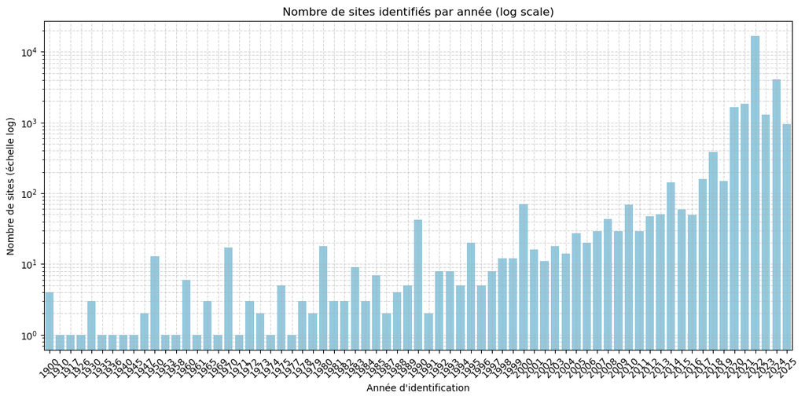

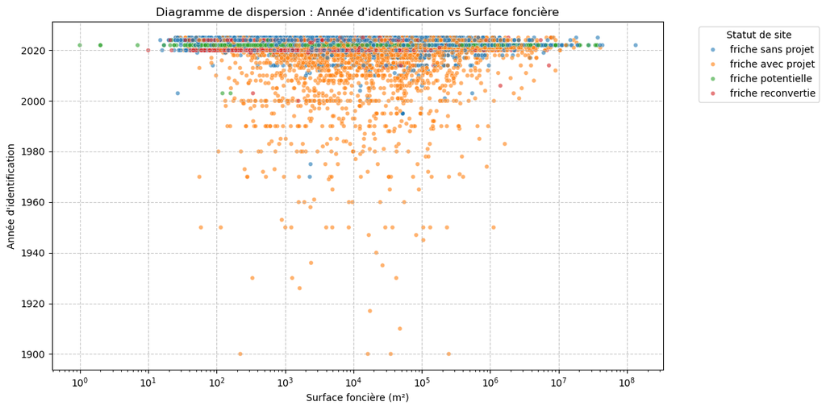

|  | colonne | valeur_manquant_reel | valeur_manquant_effectif | taux_doublons_(%) | Modalite_Dominante | Dominance_(%) | Nb_Valeurs_Uniques | Nb_Lignes_Valides_Selon_Regle | Taux_Validite_Effectif_(%) | Top3_Modalites_Non_Valides |
| --- | --- | --- | --- | --- | --- | --- | --- | --- | --- | --- |
| 0 | site_identif_date | 0 | 0 | 97.93 | 2022-10-10 | 56.0 | 581 | 28083 | 99.89 | {'14-09-23': 4, '6-09-23': 3, '12-03-24': 3} |
| 1 | site_actu_date | 0 | 0 | 98.11 | 2022-10-10 | 55.4 | 532 | 28086 | 99.90 | {'0014-09-23': 4, '0006-09-23': 3, '0012-03-24... |
| 2 | site_reconv_annee | 28115 | 28115 | 100.00 | None | NaN | 0 | 0 | 0.00 | {'nan': 28115} |
| 3 | activite_fin_annee | 24109 | 24389 | 99.74 | 2010 | 8.5 | 72 | 0 | 0.00 | {'nan': 24109, '2010': 315, 'inconnu': 280} |
| 4 | local_ancien_annee | 12772 | 12772 | 98.85 | 1900.0 | 7.5 | 323 | 14507 | 94.55 | {'nan': 12772, '1700.0': 213, '1750.0': 175} |
| 5 | local_recent_annee | 10694 | 10694 | 98.94 | 1900.0 | 5.8 | 298 | 16877 | 96.88 | {'nan': 10694, '1700.0': 139, '1750.0': 116} |
| 6 | TOTAL DOMAINE | 75690 | 75970 | 98.93 | N/A | N/A | N/A | 87553 | 94.43 | N/A |

site_identif_date Exploitable

#### Nettoyage des colonnes de dates et gestions des outliers

```
site_identif_date
str    28115
Name: count, dtype: int64
```

|  | Pattern typologique | Longueur | Exemple | Fréquence |
| --- | --- | --- | --- | --- |
| 0 | 0000X00X00 | 10 | 2025-03-05 | 28083 |
| 1 | 00X00X00 | 8 | 16-10-23 | 21 |
| 2 | 0X00X00 | 7 | 6-09-23 | 11 |

site_actu_date Exploitable

#### `site_actu_date` (date de dernière actualisation)

**Causes** : Le gros du jeu de données provient d’imports de bases externes à une date donnée (ex. intégration de BASIAS/BASOL en bloc) plutôt que de mises à jour continues. Ensuite, l’effort de mise à jour manuelle ou via les observatoires locaux a été limité, d’où peu de changement de date.  
**Recommandations** : Mettre en place un suivi des mises à jour plus systématique. Cela peut passer par des synchronisations annuelles avec les sources (si BASIAS/BASOL sont mis à jour) ou par sollicitation des acteurs locaux pour revoir les fiches. Il serait pertinent de stocker aussi la date de création initiale (manquante actuellement) pour distinguer l’ancienneté vs. la fraicheur de l’info. En attendant, on peut identifier les sites potentiellement obsolètes en calculant le délai depuis `site_actu_date` et en priorisant ceux dont la date est la plus ancienne (plus de 2–3 ans) pour vérification. (Complétion suggérée) : Une idée serait de lier Cartofriches à une API d’observatoire ou de data.gouv permettant de notifier des changements (par ex., si un site Basol change d’état, mettre à jour automatiquement), afin d’améliorer la réactivité des actualisations.

```
site_actu_date
str    28115
Name: count, dtype: int64
```

|  | Pattern typologique | Longueur | Exemple | Fréquence |
| --- | --- | --- | --- | --- |
| 0 | 0000X00X00 | 10 | 2025-03-05 | 28115 |

```
📊 Moyenne de l'ancienneté (≤ 9000 jours) : 1068.74 jours
🔹 Médiane : 967 jours
± Écart type : 889.27 jours
📈 Nombre de points : 27862 / 27862
```

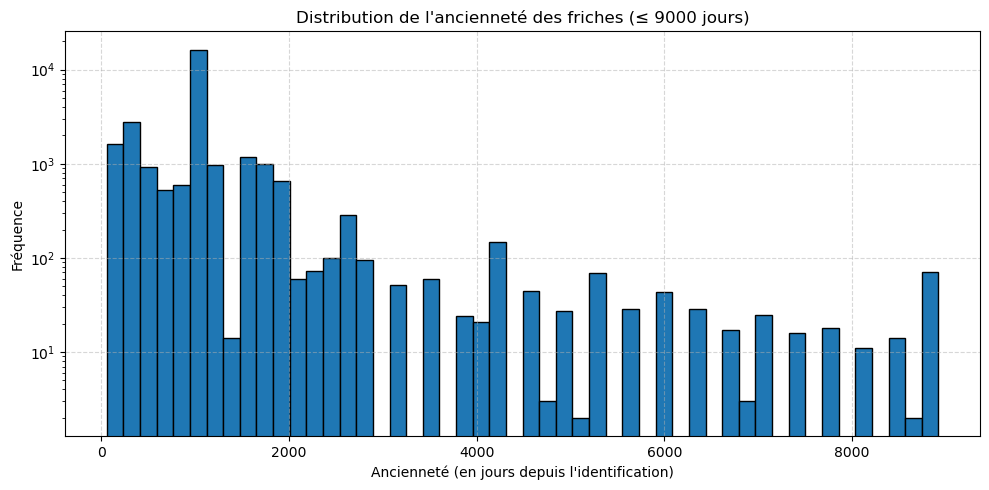

Ces variables sont les seules variables temporelles que l'on a elles indiquent la date de saisie des données et leurs mises a jour site_actu date est un bon indicateur de la qualité de la maintenance du site.  
On peut estimer le délai de mise a jour moyen des données, et aussi la récurence de ces mises à jour, il nous manquerai juste une information si jamais il y a des mises a jour multiples. On peut aussi déterminer la fréquence des mises à jour.

[interactive chart not shown]

local_xx_annee Inexploitable mais critique

#### `local_ancienne_annee` / `local_recent_annee` (années de construction du plus ancien et plus récent bâtiment)

site_reconv_annee Inexploitable

#### `site_reconv_annee` ( année de réhabilitation de la friche)

**Problème:** Ce champ est complètement vide. Le standard autorise la valeur vide mais il permettrait la traçabilité des données surtout que au moins 20% ⚠️reverifier des friches recensées sont déja reconverties.  
**Recommendations:** Ce champ n'est pas critique dans le cadre de cartofriche mais il gagnerai a être documenté pour les acteurs de l'urbanisme ou du batiment pour les futurs projet immobiliers et la traçabilité des transformations.

activite_fin_annee À surveiller

#### `activite_fin_annee` (année de fin d’activité)

⚠️ séparer les graphiques, revoir le graphique diagramme de dispersion, illisible

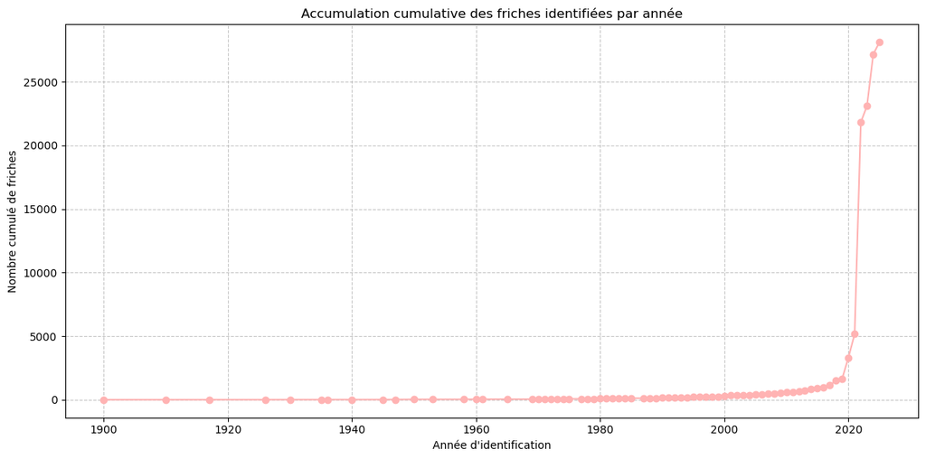

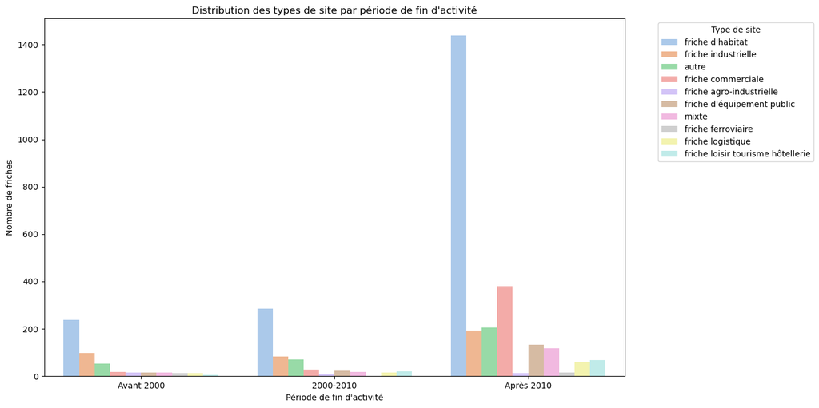

Interprétation et recommandations : Les lacunes temporelles (années manquantes) signifient qu’il faudra être prudent dans l’analyse des tendances historiques – beaucoup de sites ne peuvent pas être situés dans le temps, ce qui empêche de savoir s’ils datent par exemple de périodes industrielles spécifiques. Il serait utile d’enquêter sur les outliers identifiés : une date incohérente doit être vérifiée (peut-être s’agit-il d’une erreur de formatage, comme une confusion de siècle ou l’utilisation d’une date par défaut “1900” en cas de valeur manquante). La distribution inégale des dates suggère que certaines périodes ont été plus propices à la formation de friches (ex : déclin industriel durant une décennie donnée) ou bien que les efforts de recensement se sont intensifiés à certaines époques. Il est recommandé de contextualiser ces tendances avec l’histoire locale et de combler, si possible, les lacunes en recherchant des données supplémentaires pour les sites dont les dates sont inconnues. Visualisations suggérées : Un histogramme du nombre de friches par année (ou une courbe temporelle) pour visualiser les tendances globales et repérer les années anormalement hautes ou basses en nombre de sites. Un graphique cumulatif montrant l’accumulation des friches au fil du temps (si la date de découverte ou de mise en friche est disponible) afin de voir l’évolution du phénomène et d’identifier des points de changement. Une mise en évidence des outliers temporels, par exemple via un diagramme de dispersion où l’axe des X serait l’année et l’axe des Y une autre variable (taille du site, type, etc.), pour voir si les sites aux dates extrêmes ont des caractéristiques particulières. Un croisement entre l’ancienneté et d’autres variables (par ex. comparer la distribution des types de friches ou le statut de pollution selon les périodes) pour déceler d’éventuels liens entre l’époque de fermeture et la nature des sites.

### 📍 Données de localisation

**Interprétation et recommandations** : Les coordonnées manquantes ou imprécises limitent l’utilité du jeu de données pour des analyses cartographiques et la planification territoriale. Il serait pertinent de géocoder les adresses manquantes ou de compléter ces informations via d’autres sources afin de pouvoir intégrer tous les sites dans les études spatiales. Les anomalies repérées (coordonnées hors zone attendue) devraient être vérifiées et corrigées, car elles peuvent fausser les analyses (par exemple un site affiché à l’étranger par erreur). La détection de doublons géographiques implique d’établir une procédure de regroupement des entrées dupliquées : si deux enregistrements représentent le même site, ils devraient être fusionnés pour éviter une double comptabilisation. Enfin, la forte concentration de friches dans certains secteurs peut indiquer des zones industrielles historiques ou un effort de recensement inégal selon les communes. Il faudra en tenir compte dans l’analyse, par exemple en comparant les contextes locaux ou en normalisant par la taille de la commune ou de la population afin de relativiser ces concentrations.

|  | colonne | valeur_manquant_reel | valeur_manquant_effectif | taux_doublons_(%) | Modalite_Dominante | Dominance_(%) | Nb_Valeurs_Uniques | Nb_Lignes_Valides_Selon_Regle | Taux_Validite_Effectif_(%) | Top3_Modalites_Non_Valides |
| --- | --- | --- | --- | --- | --- | --- | --- | --- | --- | --- |
| 0 | comm_nom | 132 | 132 | 66.60 | ANGOULEME | 2.5 | 9390 | 27983 | 100.00 | {'nan': 132} |
| 1 | comm_insee | 132 | 132 | 67.49 | 16015 | 2.5 | 9138 | 27839 | 99.49 | {'nan': 132, '2a004': 17, '2a247': 6} |
| 2 | geompoint | 0 | 0 | 4.09 | POINT (3.175503 50.7054) | 0.1 | 26966 | 28115 | 100.00 | Aucune |
| 3 | geomsurf | 28115 | 28115 | 100.00 | None | NaN | 0 | 0 | 0.00 | Aucune |
| 4 | site_adresse | 24125 | 24125 | 86.79 | LE VILLAGE | 0.8 | 3713 | 3892 | 97.54 | {'nan': 24125, 'le village': 33, 'woignas': 4} |
| 5 | TOTAL DOMAINE | 52504 | 52504 | 64.99 | N/A | N/A | N/A | 87829 | 99.73 | N/A |

[interactive chart not shown]

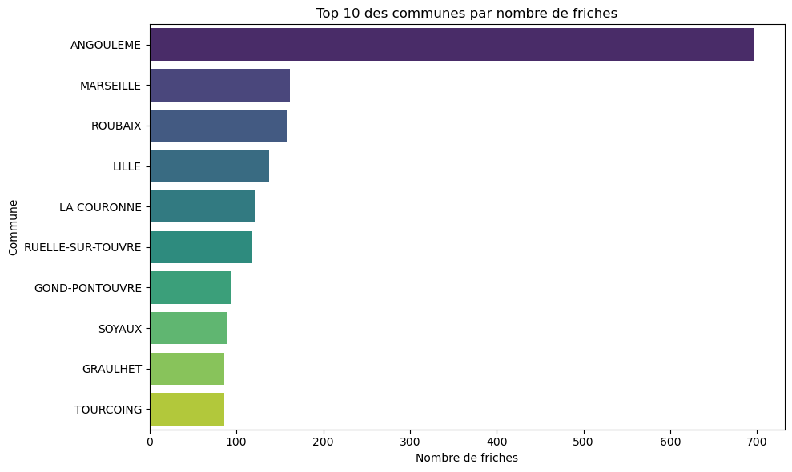

[interactive chart not shown]

comm_insee Exploitable

#### `comm_insee`* (code INSEE de la commune)

|  | Pattern typologique | Longueur | Exemple | Fréquence |
| --- | --- | --- | --- | --- |
| 0 | 00000 | 5 | 61214 | 27839 |
| 1 | 0A000 | 5 | 2B185 | 144 |

⚠️ interpoller avec d'autres colonnes essayer de comprendre pourquoi ces valeurs manquent pour proposer des correctifs durables pourtant elles sont obligatoires

comm_nom Exploitable